# Exercici 37 Especies

PIE2

Tardor 2019-2020

### En diferents àrees s’ha comptat el nombre d’espècies de plantes que hi havia (Especies). Les àrees considerades tenien diferents quantitats de biomassa (Biomassa) i també diferents valors del pH del sòl (pH),els valors del pH s’han classificat en tres nivells: alt, mitja, baix. Assumint que donat un valor de biomassa i un nivell del pH del sòl la variable pH segueix una distribució Poisson, es vol comprovar si les dues variables (Biomassa i pH) tenen algun efecte sobre en nombre d’espècies amb un nivell de significació del 5%. amb aquest objectiu:

Directori, paquets, dades …

```r
#setwd("...")
dd<-read.csv2("../data/especies.csv")
library(car)
library(emmeans)
head(dd)
```

```
##    pH  Biomassa Especies
## 1 alt 0.4692972       30
## 2 alt 1.7308704       39
## 3 alt 2.0897785       44
## 4 alt 3.9257871       35
## 5 alt 4.3667927       25
## 6 alt 5.4819747       29
```

#### a) Feu una gràfica per descriure les dades.

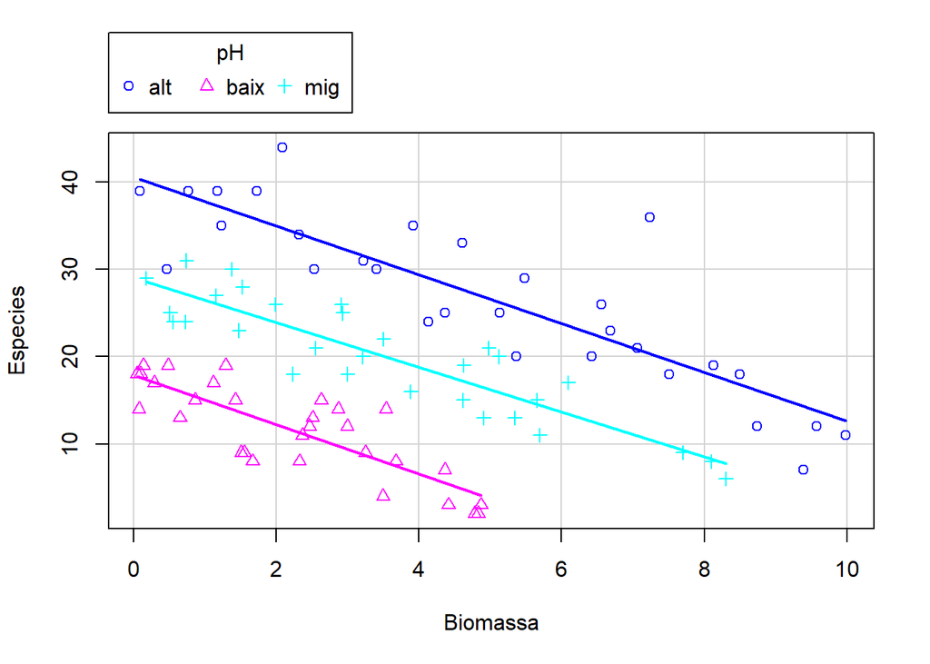

```r
sp(Especies~Biomassa|pH,smooth=F,dat=dd)
```

#### b) Ajusteu el MLG adequat utilitzant la seva funció link canònica.

```r
summary(m1<-glm(Especies~Biomassa*pH,family=poisson,data=dd))
```

```
##
## Call:
## glm(formula = Especies ~ Biomassa * pH, family = poisson, data = dd)
##
## Deviance Residuals:
##     Min       1Q   Median       3Q      Max
## -2.4978  -0.7485  -0.0402   0.5575   3.2297
##
## Coefficients:
##                 Estimate Std. Error z value Pr(>|z|)
## (Intercept)      3.76812    0.06153  61.240  < 2e-16 ***
## Biomassa        -0.10713    0.01249  -8.577  < 2e-16 ***
## pHbaix          -0.81557    0.10284  -7.931 2.18e-15 ***
## pHmig           -0.33146    0.09217  -3.596 0.000323 ***
## Biomassa:pHbaix -0.15503    0.04003  -3.873 0.000108 ***
## Biomassa:pHmig  -0.03189    0.02308  -1.382 0.166954
## ---
## Signif. codes:  0 '***' 0.001 '**' 0.01 '*' 0.05 '.' 0.1 ' ' 1
##
## (Dispersion parameter for poisson family taken to be 1)
##
##     Null deviance: 452.346  on 89  degrees of freedom
## Residual deviance:  83.201  on 84  degrees of freedom
## AIC: 514.39
##
## Number of Fisher Scoring iterations: 4
```

**i. Quins efectes són significants?**

Test Omnibus i test Anova

```r
anova(glm(Especies~1,family=poisson,data=dd),m1,test="Chisq")
```

```
## Analysis of Deviance Table
##
## Model 1: Especies ~ 1
## Model 2: Especies ~ Biomassa * pH
##   Resid. Df Resid. Dev Df Deviance  Pr(>Chi)
## 1        89     452.35
## 2        84      83.20  5   369.14 < 2.2e-16 ***
## ---
## Signif. codes:  0 '***' 0.001 '**' 0.01 '*' 0.05 '.' 0.1 ' ' 1
```

```r
Anova(m1)
```

```
## Analysis of Deviance Table (Type II tests)
##
## Response: Especies
##             LR Chisq Df Pr(>Chisq)
## Biomassa      165.88  1  < 2.2e-16 ***
## pH            308.43  2  < 2.2e-16 ***
## Biomassa:pH    16.04  2  0.0003288 ***
## ---
## Signif. codes:  0 '***' 0.001 '**' 0.01 '*' 0.05 '.' 0.1 ' ' 1
```

**• En el valor mitjà de la biomassa, quines diferències hi ha entre els efectes dels tres nivells del pH sobre el nombre d’espècies?**

```r
CLD(emmeans(m1,~pH|Biomassa),ty="response")
```

```
## Biomassa = 3.56:
##  pH    rate    SE  df asymp.LCL asymp.UCL .group
##  baix  7.54 0.682 Inf      6.31       9.0  1
##  mig  18.96 0.817 Inf     17.42      20.6   2
##  alt  29.58 1.058 Inf     27.58      31.7    3
##
## Confidence level used: 0.95
## Intervals are back-transformed from the log scale
## P value adjustment: tukey method for comparing a family of 3 estimates
## Tests are performed on the log scale
## significance level used: alpha = 0.05
```

**• i quan Biomassa= 0, 1, 5 o 9))**

```r
CLD(emmeans(m1,~pH|Biomassa,at=list(Biomassa=c(0,1,5,9))))
```

```
## Biomassa = 0:
##  pH   emmean     SE  df asymp.LCL asymp.UCL .group
##  baix  2.953 0.0824 Inf    2.7911      3.11  1
##  mig   3.437 0.0686 Inf    3.3022      3.57   2
##  alt   3.768 0.0615 Inf    3.6475      3.89    3
##
## Biomassa = 1:
##  pH   emmean     SE  df asymp.LCL asymp.UCL .group
##  baix  2.690 0.0590 Inf    2.5748      2.81  1
##  mig   3.298 0.0543 Inf    3.1913      3.40   2
##  alt   3.661 0.0518 Inf    3.5595      3.76    3
##
## Biomassa = 5:
##  pH   emmean     SE  df asymp.LCL asymp.UCL .group
##  baix  1.642 0.1385 Inf    1.3703      1.91  1
##  mig   2.742 0.0585 Inf    2.6269      2.86   2
##  alt   3.232 0.0373 Inf    3.1594      3.31    3
##
## Biomassa = 9:
##  pH   emmean     SE  df asymp.LCL asymp.UCL .group
##  baix  0.593 0.2849 Inf    0.0348      1.15  1
##  mig   2.185 0.1263 Inf    1.9380      2.43   2
##  alt   2.804 0.0713 Inf    2.6642      2.94    3
##
## Results are given on the log (not the response) scale.
## Confidence level used: 0.95
## P value adjustment: tukey method for comparing a family of 3 estimates
## significance level used: alpha = 0.05
```

```r
CLD(emmeans(m1,~pH|Biomassa,at=list(Biomassa=c(0,1,5,9))),ty="response")
```

```
## Biomassa = 0:
##  pH    rate    SE  df asymp.LCL asymp.UCL .group
##  baix 19.15 1.578 Inf     16.30     22.51  1
##  mig  31.08 2.133 Inf     27.17     35.56   2
##  alt  43.30 2.664 Inf     38.38     48.85    3
##
## Biomassa = 1:
##  pH    rate    SE  df asymp.LCL asymp.UCL .group
##  baix 14.74 0.870 Inf     13.13     16.54  1
##  mig  27.05 1.468 Inf     24.32     30.08   2
##  alt  38.90 2.015 Inf     35.14     43.06    3
##
## Biomassa = 5:
##  pH    rate    SE  df asymp.LCL asymp.UCL .group
##  baix  5.16 0.715 Inf      3.94      6.77  1
##  mig  15.51 0.907 Inf     13.83     17.39   2
##  alt  25.34 0.944 Inf     23.56     27.26    3
##
## Biomassa = 9:
##  pH    rate    SE  df asymp.LCL asymp.UCL .group
##  baix  1.81 0.516 Inf      1.04      3.16  1
##  mig   8.89 1.123 Inf      6.94     11.39   2
##  alt  16.51 1.177 Inf     14.36     18.99    3
##
## Confidence level used: 0.95
## Intervals are back-transformed from the log scale
## P value adjustment: tukey method for comparing a family of 3 estimates
## Tests are performed on the log scale
## significance level used: alpha = 0.05
```

**• Donat un nivell del pH, la variable Especies canvia en funció de la Biomassa?**

Mirar els pendents

```r
emtrends(m1,~pH,var="Biomassa")
```

```
##  pH   Biomassa.trend     SE  df asymp.LCL asymp.UCL
##  alt          -0.107 0.0125 Inf    -0.132   -0.0826
##  baix         -0.262 0.0380 Inf    -0.337   -0.1876
##  mig          -0.139 0.0194 Inf    -0.177   -0.1010
##
## Confidence level used: 0.95
```

```r
CLD(emtrends(m1,~pH,var="Biomassa"))
```

```
##  pH   Biomassa.trend     SE  df asymp.LCL asymp.UCL .group
##  baix         -0.262 0.0380 Inf    -0.337   -0.1876  1
##  mig          -0.139 0.0194 Inf    -0.177   -0.1010   2
##  alt          -0.107 0.0125 Inf    -0.132   -0.0826   2
##
## Confidence level used: 0.95
## P value adjustment: tukey method for comparing a family of 3 estimates
## significance level used: alpha = 0.05
```

**ii. Hi ha sobre o subdispersió?**

```r
c(PS=PS1<-sum(residuals(m1,type="pearson")^2),"Par.Disp"=disp1<-PS1/m1$df.res)
```

```
##         PS   Par.Disp
## 83.7481208  0.9970014
```

```r
c("P-valor"=2*min(pchisq(PS1,m1$df.res),1-pchisq(PS1,m1$df.res)))
```

```
##   P-valor
## 0.9744529
```

**iii. Aquest model és adequat per les dades obtingudes?** És adequat si l’esperança dels errors és 0 i la variància constant. Residuals

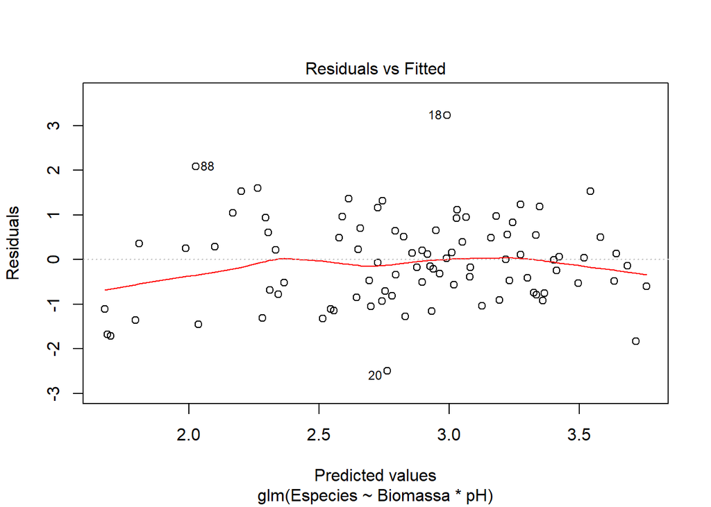

```r
plot(m1,1)
```

Valors estranys

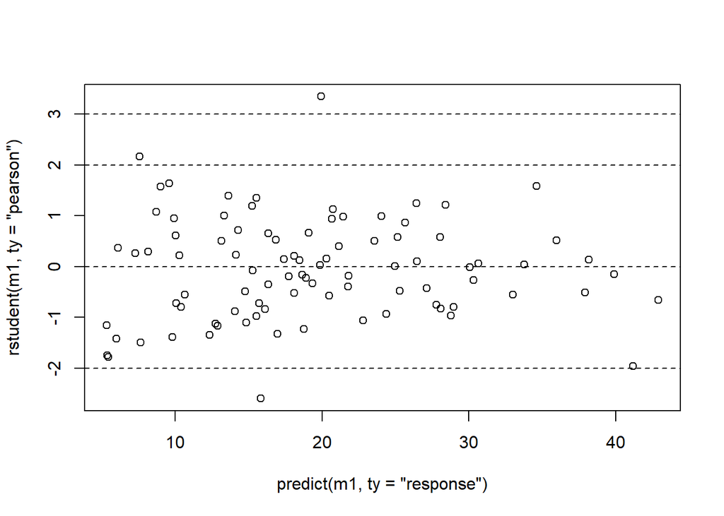

```r
plot(predict(m1,ty="response"),rstudent(m1,ty="pearson"))
abline(h=c(--3,-2,0,2,3),lty=2)
```

*La dispersió sembla bé, la tendència central duptosa, la dispersió sembla bé i hi ha algun valor estrany*

#### c) Calculeu els valors predits del nombre d’espècies:

**i. Per cada nivell del pH, doneu l’expressió de** $\hat{\mathbb{E}}\left(Especies\right)$ **en funció de la Biomassa?**

```r
family(m1)
```

```
##
## Family: poisson
## Link function: log
```

*predit(i,j)=exp(ai+bi·Biomassa)*

**ii. Feu una gràfica amb les dades experimentals i els valors predits del nombre d’espècies per cada nivell del pH.**

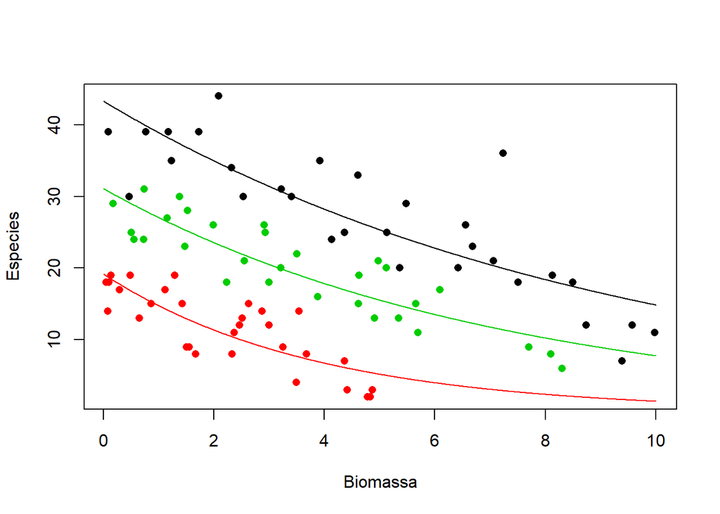

```r
bm<-seq(0,10,0.01)
plot(Especies~Biomassa,col=pH,dd,pch=16)
lines(bm,predict(m1,data.frame(Biomassa=bm,pH="alt"),ty="response"))
lines(bm,predict(m1,data.frame(Biomassa=bm,pH="baix"),ty="response"),col=2)
lines(bm,predict(m1,data.frame(Biomassa=bm,pH="mig"),ty="response"),col=3)
```

El mateix gràfic a nivell link

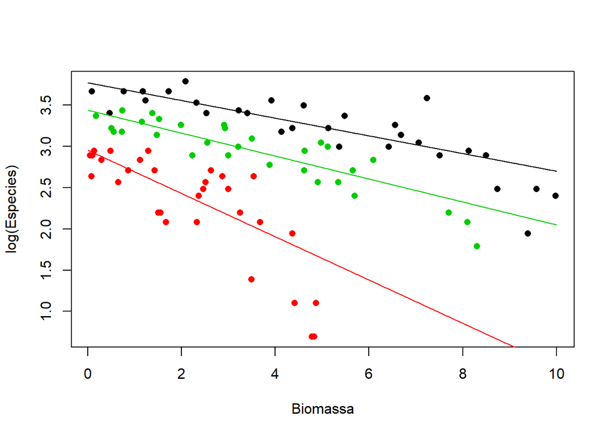

```r
plot(log(Especies)~Biomassa,col=pH,dd,pch=16)
lines(bm,predict(m1,data.frame(Biomassa=bm,pH="alt"),ty="link"))
lines(bm,predict(m1,data.frame(Biomassa=bm,pH="baix"),ty="link"),col=2)
lines(bm,predict(m1,data.frame(Biomassa=bm,pH="mig"),ty="link"),col=3)
```

**iii. Per cada nivell del pH, dibuixeu la banda de predicció asimptòtica (95%) de les Especies en funció de Biomassa.**

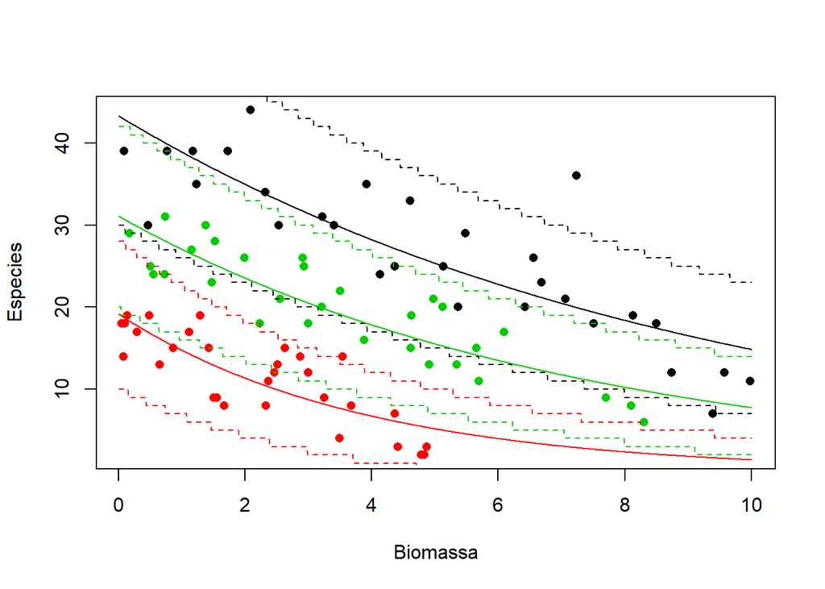

```r
# Intervals o regions de prediccio assimptòtiques:
plot(Especies~Biomassa,col=pH,dd,pch=16)
lines(bm,predict(m1,data.frame(Biomassa=bm,pH="alt"),ty="response"))
lines(bm,qpois(0.025,predict(m1,data.frame(Biomassa=bm,pH="alt"),ty="response"))-1,lty=2)
lines(bm,qpois(0.975,predict(m1,data.frame(Biomassa=bm,pH="alt"),ty="response")),lty=2)
lines(bm,predict(m1,data.frame(Biomassa=bm,pH="baix"),ty="response"),col=2)
lines(bm,qpois(0.025,predict(m1,data.frame(Biomassa=bm,pH="baix"),ty="response"))-1,lty=2,col=2)
lines(bm,qpois(0.975,predict(m1,data.frame(Biomassa=bm,pH="baix"),ty="response")),lty=2,col=2)
lines(bm,predict(m1,data.frame(Biomassa=bm,pH="mig"),ty="response"),col=3)
lines(bm,qpois(0.025,predict(m1,data.frame(Biomassa=bm,pH="mig"),ty="response"))-1,lty=2,col=3)
lines(bm,qpois(0.975,predict(m1,data.frame(Biomassa=bm,pH="mig"),ty="response")),lty=2,col=3)
```

Potser millor per separat

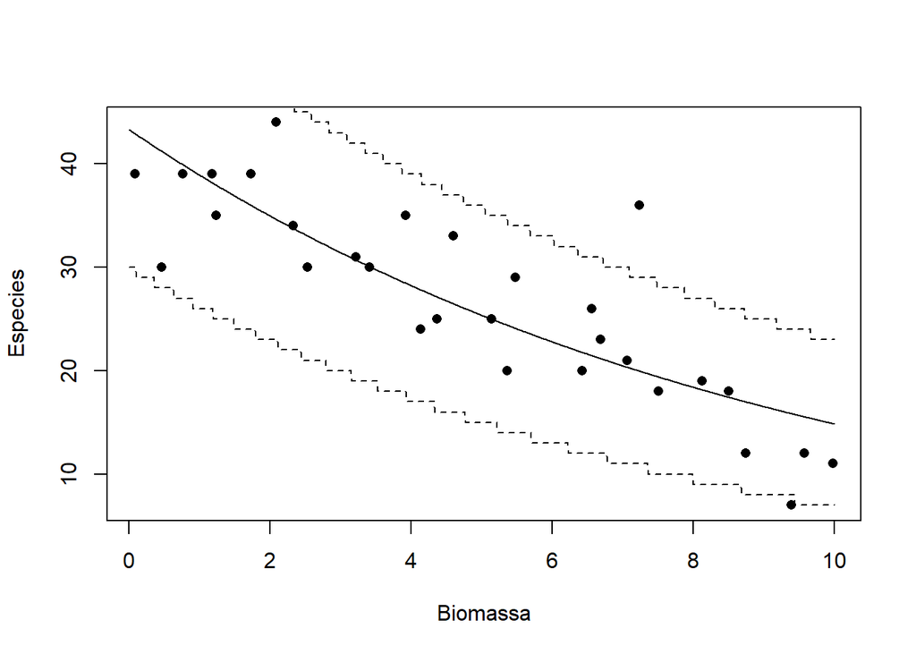

```r
plot(Especies~Biomassa,col=1,dd[dd$pH=="alt",],pch=16)
lines(bm,predict(m1,data.frame(Biomassa=bm,pH="alt"),ty="response"))
lines(bm,qpois(0.025,predict(m1,data.frame(Biomassa=bm,pH="alt"),ty="response"))-1,lty=2)
lines(bm,qpois(0.975,predict(m1,data.frame(Biomassa=bm,pH="alt"),ty="response")),lty=2)
```

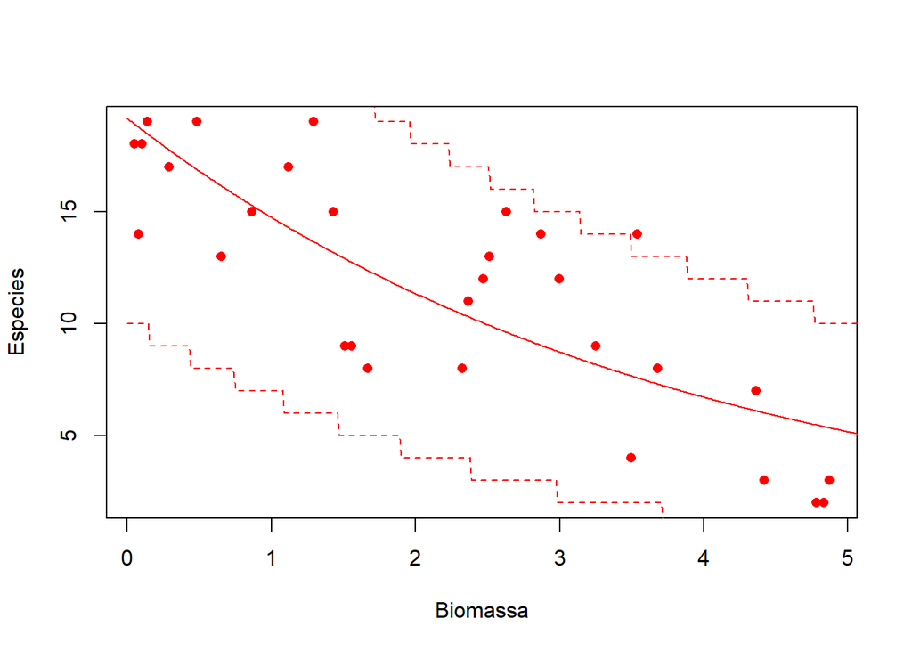

```r
plot(Especies~Biomassa,col=2,dd[dd$pH=="baix",],pch=16)
lines(bm,predict(m1,data.frame(Biomassa=bm,pH="baix"),ty="response"),col=2)
lines(bm,qpois(0.025,predict(m1,data.frame(Biomassa=bm,pH="baix"),ty="response"))-1,lty=2,col=2)
lines(bm,qpois(0.975,predict(m1,data.frame(Biomassa=bm,pH="baix"),ty="response")),lty=2,col=2)
```

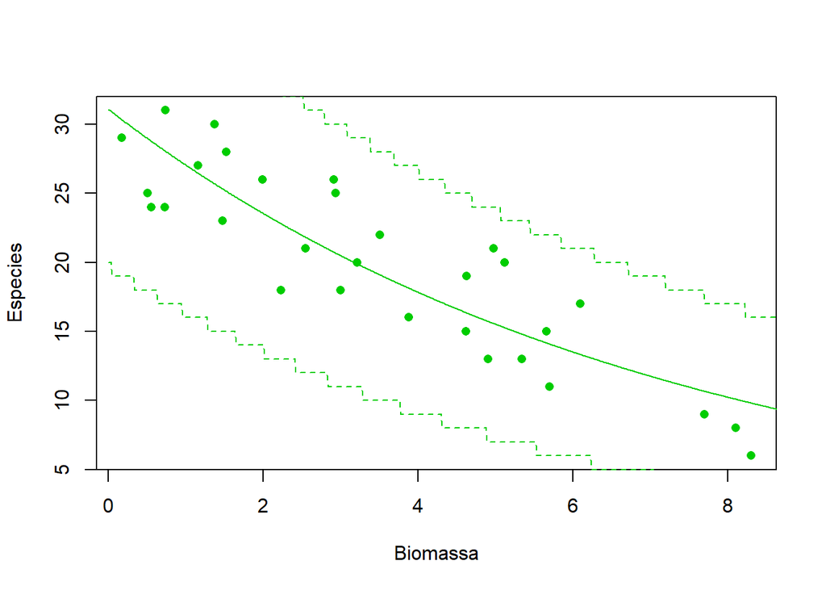

```r
plot(Especies~Biomassa,col=3,dd[dd$pH=="mig",],pch=16)
lines(bm,predict(m1,data.frame(Biomassa=bm,pH="mig"),ty="response"),col=3)
lines(bm,qpois(0.025,predict(m1,data.frame(Biomassa=bm,pH="mig"),ty="response"))-1,lty=2,col=3)
lines(bm,qpois(0.975,predict(m1,data.frame(Biomassa=bm,pH="mig"),ty="response")),lty=2,col=3)
```

**iv. Per cada nivell del pH, dibuixeu la banda de confiança (95%) de les Especies en funció de Biomassa.**

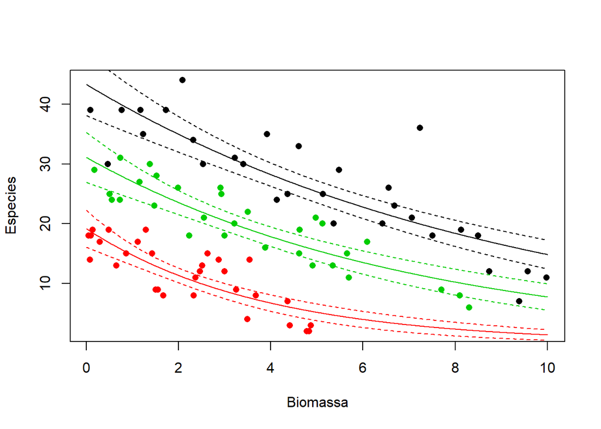

```r
palt<-predict(m1,data.frame(Biomassa=bm,pH="alt"),ty="response",se.fit=T)
pbaix<-predict(m1,data.frame(Biomassa=bm,pH="baix"),ty="response",se.fit=T)
pmig<-predict(m1,data.frame(Biomassa=bm,pH="mig"),ty="response",se.fit=T)
z<-qnorm(0.975)
plot(Especies~Biomassa,col=pH,dd,pch=16)
lines(bm,palt$fit)
lines(bm,palt$fit+z*palt$se.fit,lty=2)
lines(bm,palt$fit-z*palt$se.fit,lty=2)
lines(bm,pbaix$fit,col=2)
lines(bm,pbaix$fit+z*pbaix$se.fit,lty=2,col=2)
lines(bm,pbaix$fit-z*pbaix$se.fit,lty=2,col=2)
lines(bm,pmig$fit,col=3)
lines(bm,pmig$fit+z*pmig$se.fit,lty=2,col=3)
lines(bm,pmig$fit-z*pmig$se.fit,lty=2,col=3)
```

## Repetiu els apartats b) i c) canviant la funció link a la identitat, si es pot simplifiqueu el model. Compareu els models amb els dos links.

#### b) Ajusteu el MLG adequat utilitzant la seva funció link identitat.

```r
summary(m2<-glm(Especies~Biomassa*pH,family=poisson(link=identity),data=dd))
```

```
##
## Call:
## glm(formula = Especies ~ Biomassa * pH, family = poisson(link = identity),
##     data = dd)
##
## Deviance Residuals:
##     Min       1Q   Median       3Q      Max
## -1.9654  -0.6614  -0.0513   0.4800   3.2284
##
## Coefficients:
##                 Estimate Std. Error z value Pr(>|z|)
## (Intercept)      41.4276     2.0318  20.390  < 2e-16 ***
## Biomassa         -2.9675     0.3050  -9.731  < 2e-16 ***
## pHbaix          -22.9839     2.3597  -9.740  < 2e-16 ***
## pHmig           -12.1627     2.5642  -4.743  2.1e-06 ***
## Biomassa:pHbaix  -0.1288     0.4624  -0.278    0.781
## Biomassa:pHmig    0.3360     0.4322   0.777    0.437
## ---
## Signif. codes:  0 '***' 0.001 '**' 0.01 '*' 0.05 '.' 0.1 ' ' 1
##
## (Dispersion parameter for poisson family taken to be 1)
##
##     Null deviance: 452.35  on 89  degrees of freedom
## Residual deviance:  67.07  on 84  degrees of freedom
## AIC: 498.26
##
## Number of Fisher Scoring iterations: 6
```

**i. Quins efectes són significants?**

Test Omnibus i test Anova

```r
anova(glm(Especies~1,family=poisson(link=identity),data=dd),m2,test="Chisq")
```

```
## Analysis of Deviance Table
##
## Model 1: Especies ~ 1
## Model 2: Especies ~ Biomassa * pH
##   Resid. Df Resid. Dev Df Deviance  Pr(>Chi)
## 1        89     452.35
## 2        84      67.07  5   385.28 < 2.2e-16 ***
## ---
## Signif. codes:  0 '***' 0.001 '**' 0.01 '*' 0.05 '.' 0.1 ' ' 1
```

```r
Anova(m2)
```

```
## Analysis of Deviance Table (Type II tests)
##
## Response: Especies
##             LR Chisq Df Pr(>Chisq)
## Biomassa      196.99  1     <2e-16 ***
## pH            339.79  2     <2e-16 ***
## Biomassa:pH     1.06  2     0.5897
## ---
## Signif. codes:  0 '***' 0.001 '**' 0.01 '*' 0.05 '.' 0.1 ' ' 1
```

*Simplifiquem el model treient la interacció*

```r
summary(m2<-glm(Especies~Biomassa+pH,family=poisson(link=identity),data=dd))
```

```
##
## Call:
## glm(formula = Especies ~ Biomassa + pH, family = poisson(link = identity),
##     data = dd)
##
## Deviance Residuals:
##     Min       1Q   Median       3Q      Max
## -2.0481  -0.7142  -0.0022   0.4986   3.1957
##
## Coefficients:
##             Estimate Std. Error z value Pr(>|z|)
## (Intercept)   40.860      1.407  29.037   <2e-16 ***
## Biomassa      -2.871      0.183 -15.684   <2e-16 ***
## pHbaix       -23.068      1.180 -19.548   <2e-16 ***
## pHmig        -10.508      1.195  -8.791   <2e-16 ***
## ---
## Signif. codes:  0 '***' 0.001 '**' 0.01 '*' 0.05 '.' 0.1 ' ' 1
##
## (Dispersion parameter for poisson family taken to be 1)
##
##     Null deviance: 452.346  on 89  degrees of freedom
## Residual deviance:  68.126  on 86  degrees of freedom
## AIC: 495.32
##
## Number of Fisher Scoring iterations: 6
```

```r
anova(glm(Especies~1,family=poisson(link=identity),data=dd),m2,test="Chisq")
```

```
## Analysis of Deviance Table
##
## Model 1: Especies ~ 1
## Model 2: Especies ~ Biomassa + pH
##   Resid. Df Resid. Dev Df Deviance  Pr(>Chi)
## 1        89     452.35
## 2        86      68.13  3   384.22 < 2.2e-16 ***
## ---
## Signif. codes:  0 '***' 0.001 '**' 0.01 '*' 0.05 '.' 0.1 ' ' 1
```

```r
Anova(m2)
```

```
## Analysis of Deviance Table (Type II tests)
##
## Response: Especies
##          LR Chisq Df Pr(>Chisq)
## Biomassa   196.99  1  < 2.2e-16 ***
## pH         339.79  2  < 2.2e-16 ***
## ---
## Signif. codes:  0 '***' 0.001 '**' 0.01 '*' 0.05 '.' 0.1 ' ' 1
```

**• En el valor mitjà de la biomassa, quines diferències hi ha entre els efectes dels tres nivells del pH sobre el nombre d’espècies?**

```r
CLD(emmeans(m2,~pH|Biomassa),ty="response")
```

```
## Biomassa = 3.56:
##  pH   emmean    SE  df asymp.LCL asymp.UCL .group
##  baix   7.58 0.563 Inf      6.48      8.68  1
##  mig   20.14 0.780 Inf     18.61     21.67   2
##  alt   30.65 0.992 Inf     28.70     32.59    3
##
## Confidence level used: 0.95
## P value adjustment: tukey method for comparing a family of 3 estimates
## significance level used: alpha = 0.05
```

**• i quan Biomassa= 0, 1, 5 o 9)), de fet no cal**

```r
CLD(emmeans(m2,~pH|Biomassa,at=list(Biomassa=c(0,1,5,9))),ty="response")
```

```
## Biomassa = 0:
##  pH   emmean    SE  df asymp.LCL asymp.UCL .group
##  baix  17.79 0.779 Inf     16.26     19.32  1
##  mig   30.35 1.130 Inf     28.14     32.57   2
##  alt   40.86 1.407 Inf     38.10     43.62    3
##
## Biomassa = 1:
##  pH   emmean    SE  df asymp.LCL asymp.UCL .group
##  baix  14.92 0.663 Inf     13.62     16.22  1
##  mig   27.48 1.001 Inf     25.52     29.44   2
##  alt   37.99 1.271 Inf     35.50     40.48    3
##
## Biomassa = 5:
##  pH   emmean    SE  df asymp.LCL asymp.UCL .group
##  baix   3.44 0.665 Inf      2.13      4.74  1
##  mig   16.00 0.761 Inf     14.51     17.49   2
##  alt   26.50 0.907 Inf     24.73     28.28    3
##
## Biomassa = 9:
##  pH   emmean    SE  df asymp.LCL asymp.UCL .group
##  baix  -8.05 1.231 Inf    -10.46     -5.63  1
##  mig    4.51 1.108 Inf      2.34      6.68   2
##  alt   15.02 1.050 Inf     12.96     17.08    3
##
## Confidence level used: 0.95
## P value adjustment: tukey method for comparing a family of 3 estimates
## significance level used: alpha = 0.05
```

**• Donat un nivell del pH, la variable Especies canvia en funció de la Biomassa?**

Mirar els pendents

```r
emtrends(m2,~pH,var="Biomassa")
```

```
##  pH   Biomassa.trend    SE  df asymp.LCL asymp.UCL
##  alt           -2.87 0.183 Inf     -3.23     -2.51
##  baix          -2.87 0.183 Inf     -3.23     -2.51
##  mig           -2.87 0.183 Inf     -3.23     -2.51
##
## Confidence level used: 0.95
```

**ii. Hi ha sobre o subdispersió?**

```r
c(PS=PS2<-sum(residuals(m2,type="pearson")^2),"Par.Disp"=disp2<-PS2/m2$df.res)
```

```
##         PS   Par.Disp
## 69.8034622  0.8116682
```

```r
c("P-valor"=2*min(pchisq(PS2,m2$df.res),1-pchisq(PS2,m2$df.res)))
```

```
##   P-valor
## 0.2038653
```

**iii. Aquest model és adequat per les dades obtingudes?**

Residuals

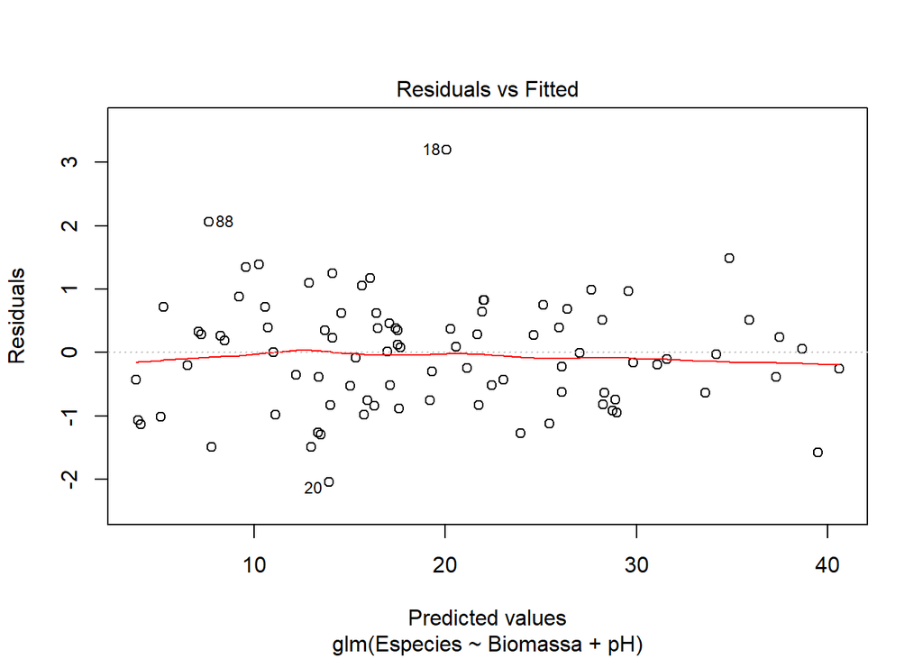

```r
plot(m2,1)
```

Valors estranys

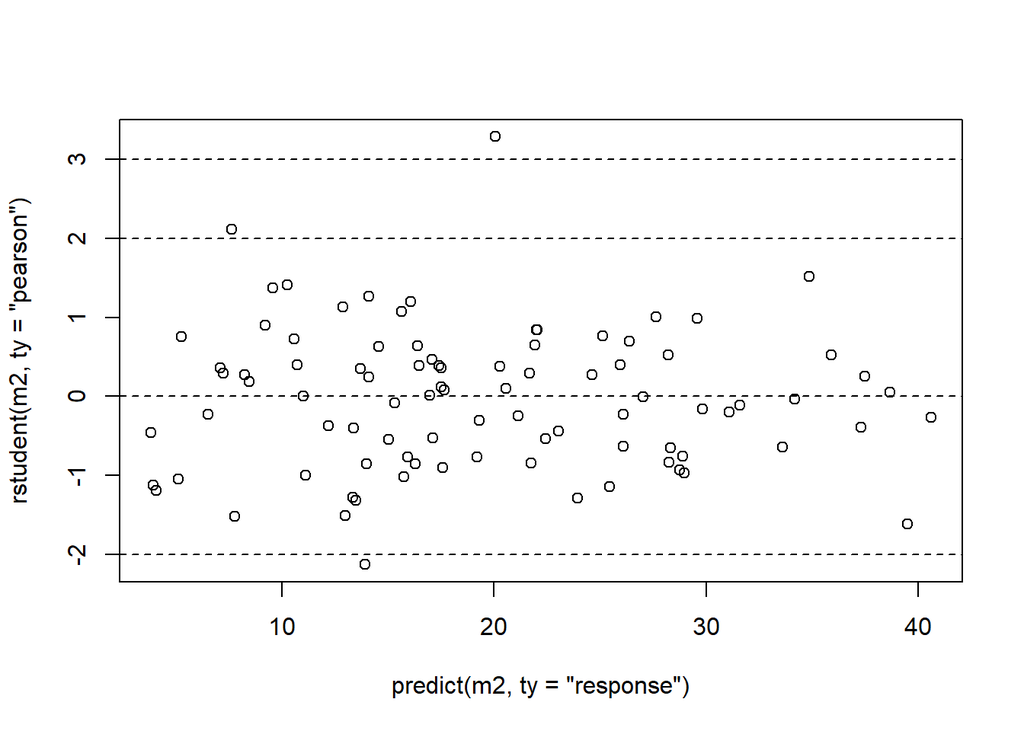

```r
plot(predict(m2,ty="response"),rstudent(m2,ty="pearson"))
abline(h=c(--3,-2,0,2,3),lty=2)
```

*La dispersió sembla bé, la tendència sembla bé, la dispersió sembla bé i hi ha algun valor estrany*

#### c) Calculeu els valors predits del nombre d’espècies:

**i. Per cada nivell del pH, doneu l’expressió de** $\hat{\mathbb{E}}\left(Especies\right)$ **en funció de la Biomassa?**

```r
family(m2)
```

```
##
## Family: poisson
## Link function: identity
```

*predit(i,j)=(ai+bi·Biomassa)*

**ii. Feu una gràfica amb les dades experimentals i els valors predits del nombre d’espècies per cada nivell del pH.**

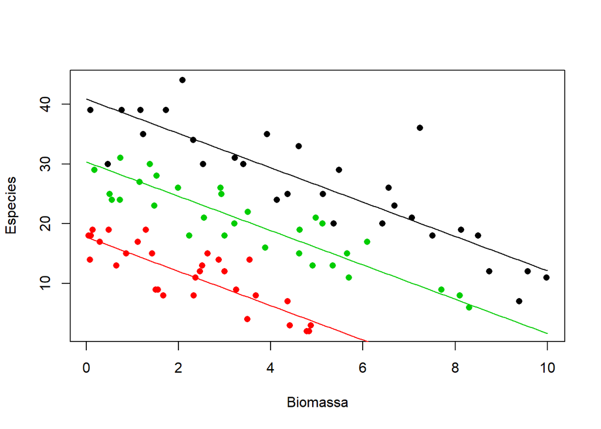

```r
bm<-seq(0,10,0.1)
plot(Especies~Biomassa,col=pH,dd,pch=16)
lines(bm,predict(m2,data.frame(Biomassa=bm,pH="alt"),ty="response"))
lines(bm,predict(m2,data.frame(Biomassa=bm,pH="baix"),ty="response"),col=2)
lines(bm,predict(m2,data.frame(Biomassa=bm,pH="mig"),ty="response"),col=3)
```

**iii. Per cada nivell del pH, dibuixeu la banda de predicció asimptòtica (95%) de les Especies en funció de Biomassa.**

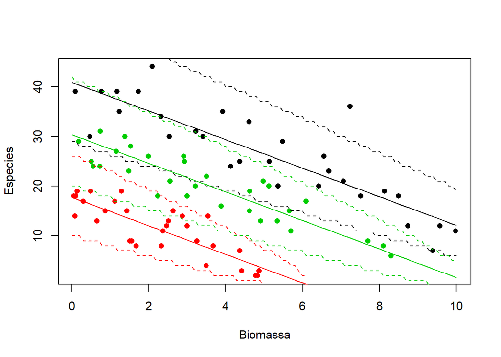

```r
plot(Especies~Biomassa,col=pH,dd,pch=16)
lines(bm,predict(m2,data.frame(Biomassa=bm,pH="alt"),ty="response"))
lines(bm,qpois(0.025,predict(m2,data.frame(Biomassa=bm,pH="alt"),ty="response")),lty=2)
lines(bm,qpois(0.975,predict(m2,data.frame(Biomassa=bm,pH="alt"),ty="response")),lty=2)
lines(bm,predict(m2,data.frame(Biomassa=bm,pH="baix"),ty="response"),col=2)
lines(bm,qpois(0.025,predict(m2,data.frame(Biomassa=bm,pH="baix"),ty="response")),lty=2,col=2)
lines(bm,qpois(0.975,predict(m2,data.frame(Biomassa=bm,pH="baix"),ty="response")),lty=2,col=2)
lines(bm,predict(m2,data.frame(Biomassa=bm,pH="mig"),ty="response"),col=3)
lines(bm,qpois(0.025,predict(m2,data.frame(Biomassa=bm,pH="mig"),ty="response")),lty=2,col=3)
lines(bm,qpois(0.975,predict(m2,data.frame(Biomassa=bm,pH="mig"),ty="response")),lty=2,col=3)
```

Potser millor per separat

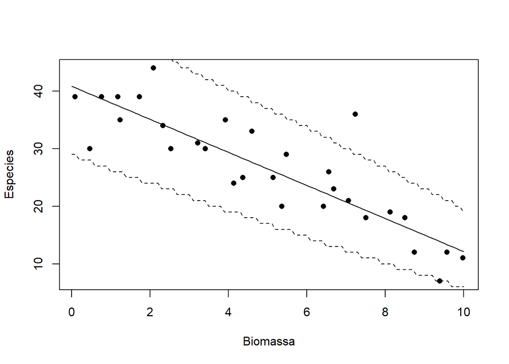

```r
plot(Especies~Biomassa,col=1,dd[dd$pH=="alt",],pch=16)
lines(bm,predict(m2,data.frame(Biomassa=bm,pH="alt"),ty="response"))
lines(bm,qpois(0.025,predict(m2,data.frame(Biomassa=bm,pH="alt"),ty="response")),lty=2)
lines(bm,qpois(0.975,predict(m2,data.frame(Biomassa=bm,pH="alt"),ty="response")),lty=2)
```

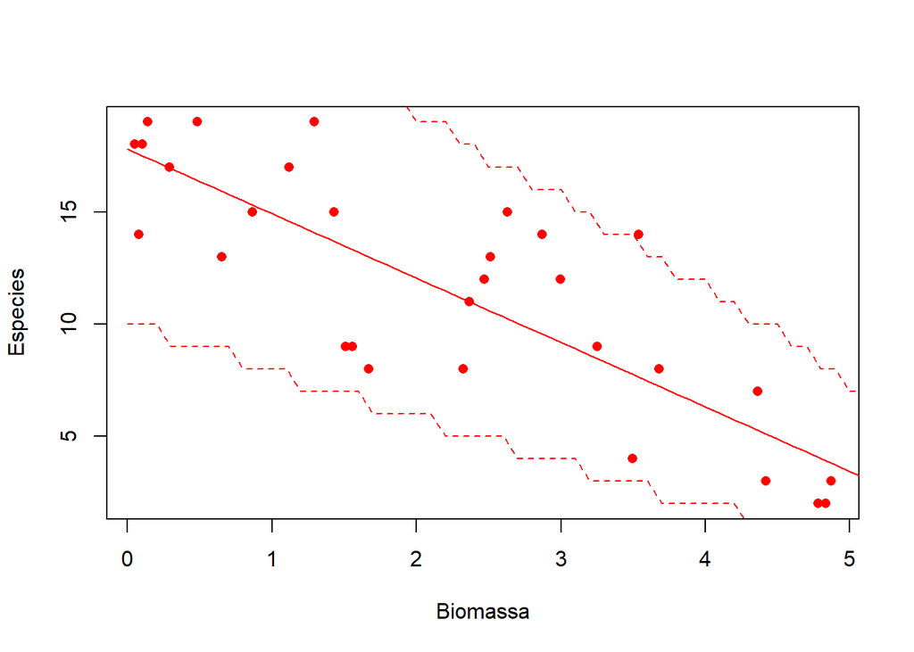

```r
plot(Especies~Biomassa,col=2,dd[dd$pH=="baix",],pch=16)
lines(bm,predict(m2,data.frame(Biomassa=bm,pH="baix"),ty="response"),col=2)
lines(bm,qpois(0.025,predict(m2,data.frame(Biomassa=bm,pH="baix"),ty="response")),lty=2,col=2)
lines(bm,qpois(0.975,predict(m2,data.frame(Biomassa=bm,pH="baix"),ty="response")),lty=2,col=2)
```

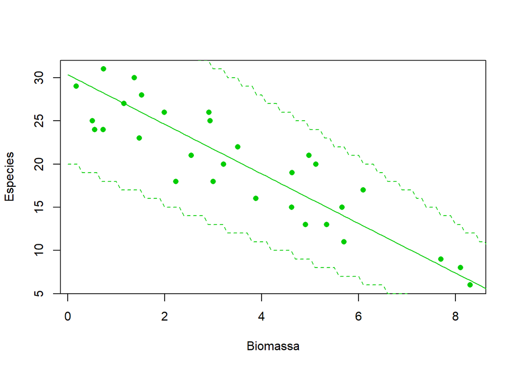

```r
plot(Especies~Biomassa,col=3,dd[dd$pH=="mig",],pch=16)
lines(bm,predict(m2,data.frame(Biomassa=bm,pH="mig"),ty="response"),col=3)
lines(bm,qpois(0.025,predict(m2,data.frame(Biomassa=bm,pH="mig"),ty="response")),lty=2,col=3)
lines(bm,qpois(0.975,predict(m2,data.frame(Biomassa=bm,pH="mig"),ty="response")),lty=2,col=3)
```

**iv. Per cada nivell del pH, dibuixeu la banda de confiança (95%) de les Especies en funció de Biomassa.**

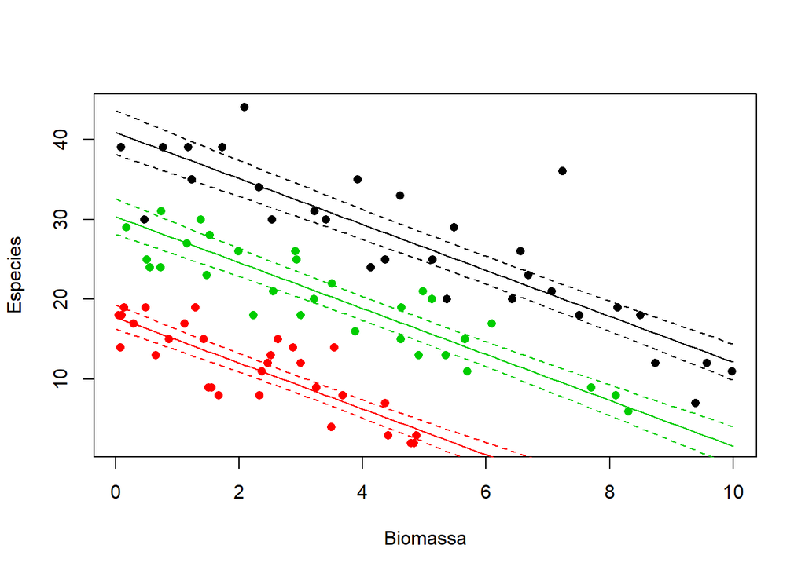

```r
palt<-predict(m2,data.frame(Biomassa=bm,pH="alt"),ty="response",se.fit=T)
pbaix<-predict(m2,data.frame(Biomassa=bm,pH="baix"),ty="response",se.fit=T)
pmig<-predict(m2,data.frame(Biomassa=bm,pH="mig"),ty="response",se.fit=T)
z<-qnorm(0.975)
plot(Especies~Biomassa,col=pH,dd,pch=16)
lines(bm,palt$fit)
lines(bm,palt$fit+z*palt$se.fit,lty=2)
lines(bm,palt$fit-z*palt$se.fit,lty=2)
lines(bm,pbaix$fit,col=2)
lines(bm,pbaix$fit+z*pbaix$se.fit,lty=2,col=2)
lines(bm,pbaix$fit-z*pbaix$se.fit,lty=2,col=2)
lines(bm,pmig$fit,col=3)
lines(bm,pmig$fit+z*pmig$se.fit,lty=2,col=3)
lines(bm,pmig$fit-z*pmig$se.fit,lty=2,col=3)
```

**Comparacions**

```r
rbind("Canònic"=c(Deviancia=m1$deviance,Pearson=PS1,Par.disp=disp1,LogLik=logLik(m1),AIC=AIC(m1)),
      "Identitat"=c(m2$deviance,PS2,disp2,logLik(m2),AIC(m2)))
```

```
##           Deviancia  Pearson  Par.disp    LogLik      AIC
## Canònic    83.20114 83.74812 0.9970014 -251.1957 514.3913
## Identitat  68.12581 69.80346 0.8116682 -243.6580 495.3160
```